# linearspline Overview

Creagh Briercliffe

2014-11-21

## Package Overview

This package provides functions for fitting a linear regression spline to a set of data and for predicting responses from the spline model to allow for analysis and plotting.

Linear spline regression works by fitting piece-wise linear functions to segments of the data between connecting points, called **knots**. One benefit of linear spline regression is that it can produce a better local fit of the data between the knots. This flexible model can help capture non-linear trends simply by adjusting the number of the knots.

## Functions

First, load the package:

```r
library(linearspline)
```

### lmspline

This is the main function for the package that returns a list of coefficients and knots used to fit a linear spline to the given data. Given a number of knots, `nknots`, this function will place `nknots` knots at evenly spaced quantiles of the data, and fit a linear regression spline.

The `lmspline` function relies on a helper function, `create.cov` to calculate the matrix of covariates to be fit using regression methods. The `create.cov` function is not exported with the package and hence cannot be called directly by the user.

*Example 1:*

```r
# Generate some data
x <- rnorm(100, 0, 1)
y <- 3 + pmin(2* x, 0) + rnorm(1, 0, 1)

# Fit a linear spline to the data
lmspline(x, y, nknots = 1)
```

```
## $fit
##
## Call:
## lm(formula = y ~ m)
##
## Coefficients:
## (Intercept)           m1           m2
##        3.69         2.09        -1.95
##
##
## $knots
##     50%
## -0.1655
```

Now, for a more involved example using the Gapminder dataset.

*Example 2:*

```r
library(plyr)
suppressPackageStartupMessages(library(dplyr))

# Load the Gapminder dataset
gd_url <- "http://tiny.cc/gapminder"
gDat <- read.delim(file = gd_url)

# Extract the data for the countries in the continent Americas
aDat <- gDat %>% filter(continent == "Americas") %>% droplevels()

# Calculate the linear spline fit for each country in the Americas
# We will regress life expectancy on GDP per capita
spline_by_ctry <- dlply(aDat, ~country, function(x){lmspline(x$gdpPercap, x$lifeExp, nknots = 2)})

# Print the linear spline fitted to the country Canada
spline_by_ctry$Canada
```

```
## $fit
##
## Call:
## lm(formula = y ~ m)
##
## Coefficients:
## (Intercept)           m1           m2           m3
##    6.39e+01     4.88e-04     7.51e-05    -2.27e-04
##
##
## $knots
## 33.33% 66.67%
##  18006  26437
```

### pred.spline

This function accepts a linear spline model (created using `lmspline`) and a set of explanatory variables, for which it returns the predictions. This function can be used for prediction on new data as well as for plotting.

*Example 1:*

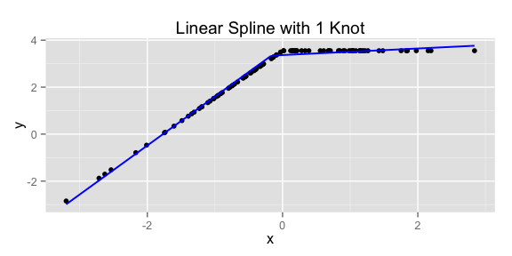

```r
library(ggplot2)

# Use the generated data from Example 1 above
lspline <- lmspline(x, y, nknots = 1)

# Plot the data and fitted spline using the pred.spline function
df <- data.frame(x,y)
ggplot(df, aes(x, y)) + geom_point() + ggtitle("Linear Spline with 1 Knot") +
    stat_function(fun = pred.spline, args = list(lspline), colour = 'blue', size = 0.7)
```

*Example 2:*

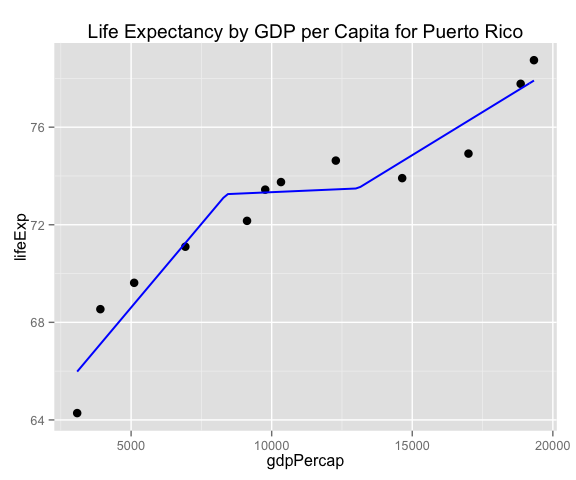

```r
# Create a plot of the fitted spline for the country Puerto Rico
aDat  %>% filter(country == "Puerto Rico") %>%
  ggplot(aes(x = gdpPercap, y = lifeExp)) + geom_point(size = 3) +
  ggtitle("Life Expectancy by GDP per Capita for Puerto Rico") +
    stat_function(fun = pred.spline,args = list(spline_by_ctry$'Puerto Rico'),colour = 'blue',size = 0.7)
```

Let’s look at one more example using more knots this time.

*Example 3:*

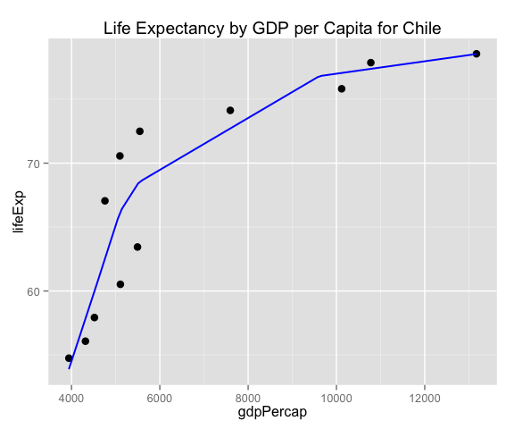

```r
# Repeat the same procedure as above, but increase to 4 knots
spline_by_ctry4 <- dlply(aDat, ~country, function(x){lmspline(x$gdpPercap, x$lifeExp, nknots = 4)})

# Create a plot of the fitted spline for the country Chile
aDat  %>% filter(country == "Chile") %>%
  ggplot(aes(x = gdpPercap, y = lifeExp)) + geom_point(size = 3) +
  ggtitle("Life Expectancy by GDP per Capita for Chile") +
    stat_function(fun = pred.spline,args = list(spline_by_ctry4$Chile),colour = 'blue',size = 0.7)
```

## Theory

A linear spline is a continuous function formed by connecting linear segments. The points where the segments connect are called the knots of the spline. Consider the following family of functions for one variable, $x$.

$f_k(x) = (x - \kappa_k)_+ = \begin{cases} x - \kappa_k & \text{ if } x > \kappa_k \\ 0 & \text{ otherwise } \end{cases}$

where $\kappa_k, 1 \leq k \leq K,$ are the knots (to be chosen). Then the equation for the linear spline is given by the following.

$\mathbb{E}(Y | x) = \beta_0 + \beta_1 x + \sum_{k = 1}^K \beta_{k + 1} f_k(x)$

The knots for a spline can be chosen arbitrarily, although it is customary to select them based on sample quantiles of the observed data, $x$. The `lmspline` function accepts as an argument the number of knots ($K$, in this formula). Then, the knots $k$ from $1$ to $K$ are chosen as equally spaced sample quantiles of the data, by the following formula.

$\kappa_k = \left( \frac{k}{K + 1} \right) 100\% \text{ quantile of the observed $x$}$

Thus, the design matrix for a dataset of size $n$, computed by the helper function `create.cov`, will take the following form.

$\mathbf{X} = \begin{pmatrix} 1 & x_1 & (x_1 - \kappa_1)_+ & \cdots & (x_1 - \kappa_K)_+ \\ 1 & x_2 & (x_2 - \kappa_1)_+ & \cdots & (x_2 - \kappa_K)_+ \\ \vdots & \vdots & \vdots & \ddots & \vdots \\ 1 & x_n & (x_n - \kappa_1)_+ & \cdots & (x_n - \kappa_K)_+ \end{pmatrix}$

Once we have the above design matrix, fitting a linear spline simply reverts to a linear regression problem, where the coefficients are chosen as the least squares solution to the equation $\mathbf{Y} = \beta \mathbf{X} + \epsilon$.

## More Examples

One final exapmle using Boston housing data available in the library `MASS`.

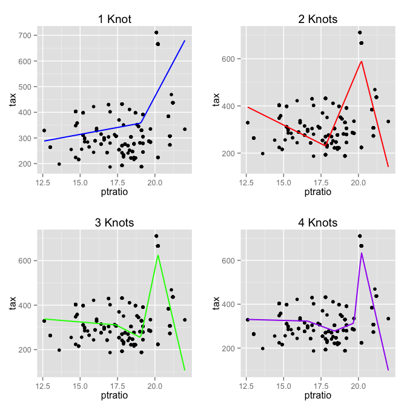

```r
# Import the Boston housing data
data(Boston, package='MASS')

# Create the linear spline fit with 4 knots
bstn_spline4 <- lmspline(Boston$ptratio, Boston$tax, nknots = 4)
# Create another linear spline fit with 3 knots
bstn_spline3 <- lmspline(Boston$ptratio, Boston$tax, nknots = 3)
# Create another linear spline fit with 2 knots
bstn_spline2 <- lmspline(Boston$ptratio, Boston$tax, nknots = 2)
# Create another linear spline fit with 1 knot
bstn_spline1 <- lmspline(Boston$ptratio, Boston$tax, nknots = 1)

# Create plots of the linear splines on the data
p <- ggplot(Boston, aes(x = ptratio, y = tax)) + geom_point()
p4 <- p + ggtitle("4 Knots") +
    stat_function(fun = pred.spline, args = list(bstn_spline4), colour = 'purple', size = 0.7)
p3 <- p + ggtitle("3 Knots") +
    stat_function(fun = pred.spline, args = list(bstn_spline3), colour = 'green', size = 0.7)
p2 <- p + ggtitle("2 Knots") +
    stat_function(fun = pred.spline, args = list(bstn_spline2), colour = 'red', size = 0.7)
p1 <- p + ggtitle("1 Knot") +
    stat_function(fun = pred.spline, args = list(bstn_spline1), colour = 'blue', size = 0.7)

# Arrange the plots in a grid
suppressPackageStartupMessages(library(gridExtra))
grid.arrange(p1, p2, p3, p4, ncol = 2)
```

## Discussion

As an idea for future work, it would be nice to extend the `lmspline` function to accept either the number of knots to choose, or a vector of already chosen knots. In this way, the user could then specify the placement of the knots, in order to better fit a dataset that can be examined beforehand.